# Willingness to Pay for Battery Information on Used BEVs

# 1 Summary of MXL Model Results

## 1.1 Preference Space

### 1.1.1 Car

```
=================================================

Model estimated on: Tue Feb 24 10:32:49 2026

Using logitr version: 1.1.2

Call:
logitr(data = data, outcome = "choice", obsID = "obsID", pars = c("price",
    "mileage", "battery_range_year0", "battery_degradation",
    "battery_refurbishpackreplace", "battery_refurbishcellreplace",
    "no_choice"), scalePar = set.seed(123), randPars = randPars,
    panelID = "respID", numMultiStarts = 10, drawType = "sobol",
    numDraws = numDraws, numCores = 5)

Frequencies of alternatives:
      1       2       3       4
0.21954 0.25550 0.23435 0.29061

Summary Of Multistart Runs:
   Log Likelihood Iterations Exit Status
1       -2551.073         28           3
2       -2554.519         22           3
3       -2553.547         23           3
4       -2550.338         23           3
5       -2554.127         21           3
6       -2555.037         21           3
7       -2553.122         21           3
8       -2551.742         26           3
9       -2553.353         21           3
10      -2551.492         23           3

Use statusCodes() to view the meaning of each status code

Exit Status: 3, Optimization stopped because ftol_rel or ftol_abs was reached.

Model Type:       Mixed Logit
Model Space:       Preference
Model Run:            4 of 10
Iterations:                23
Elapsed Time:        0h:0m:3s
```

[output cut: 28 more lines]

```
Number of Observations:  2364.0000000

Summary of 10k Draws for Random Coefficients:
                             Min.    1st Qu.     Median       Mean      3rd Qu.
mileage                      -Inf -0.6018222 -0.2402243 -0.2398833  0.121496934
battery_range_year0          -Inf -0.4016666  0.6507901  0.6517364  1.703581064
battery_degradation          -Inf -0.5498724 -0.3422074 -0.3419849 -0.134600843
battery_refurbishpackreplace -Inf -0.8083016 -0.4067041 -0.4061934 -0.005225979
battery_refurbishcellreplace -Inf -0.8600574 -0.3553776 -0.3564071  0.148966677
                             Max.
mileage                       Inf
battery_range_year0           Inf
battery_degradation           Inf
battery_refurbishpackreplace  Inf
battery_refurbishcellreplace  Inf
```

### 1.1.2 SUV

[output not shown]

[output cut: 28 more lines]

[output not shown]

## 1.2 WTP Space

### 1.2.1 Car

```
=================================================

Model estimated on: Tue Feb 24 10:35:35 2026

Using logitr version: 1.1.2

Call:
logitr(data = data, outcome = "choice", obsID = "obsID", pars = c("mileage",
    "battery_range_year0", "battery_degradation", "battery_refurbishpackreplace",
    "battery_refurbishcellreplace", "no_choice"), scalePar = "price",
    randPars = randPars, randScale = set.seed(6789), panelID = "respID",
    startVals = wtp_pref_model$Estimate, numMultiStarts = 10,
    drawType = "sobol", numDraws = numDraws, numCores = 5)

Frequencies of alternatives:
      1       2       3       4
0.21954 0.25550 0.23435 0.29061

Summary Of Multistart Runs:
   Log Likelihood Iterations Exit Status
1       -2611.878         85           4
2       -2556.789         28           3
3       -2552.828         37           3
4       -2618.362         71           4
5       -2617.624         75           4
6       -2613.182         85           3
7       -2550.768         35           3
8       -2611.927         75           3
9       -2612.920         75           4
10      -2553.002         30           3

Use statusCodes() to view the meaning of each status code

Exit Status: 3, Optimization stopped because ftol_rel or ftol_abs was reached.

Model Type:           Mixed Logit
Model Space:   Willingness-to-Pay
Model Run:                7 of 10
Iterations:                    35
Elapsed Time:           0h:0m:12s
```

[output cut: 28 more lines]

```
Number of Observations:  2364.0000000

Summary of 10k Draws for Random Coefficients:
                             Min.    1st Qu.     Median       Mean     3rd Qu.
mileage                      -Inf -0.8136231 -0.3273754 -0.3269167  0.15903848
battery_range_year0          -Inf -0.6853477  0.7751979  0.7738851  2.23527962
battery_degradation          -Inf -0.7533088 -0.4561617 -0.4564802 -0.15893091
battery_refurbishpackreplace -Inf -1.2314832 -0.5875072 -0.5866883  0.05627736
battery_refurbishcellreplace -Inf -1.1089576 -0.4948285 -0.4960813  0.11889224
                             Max.
mileage                       Inf
battery_range_year0           Inf
battery_degradation           Inf
battery_refurbishpackreplace  Inf
battery_refurbishcellreplace  Inf
```

### 1.2.2 SUV

```
=================================================

Model estimated on: Tue Feb 24 10:36:16 2026

Using logitr version: 1.1.2

Call:
logitr(data = data, outcome = "choice", obsID = "obsID", pars = c("mileage",
    "battery_range_year0", "battery_degradation", "battery_refurbishpackreplace",
    "battery_refurbishcellreplace", "no_choice"), scalePar = "price",
    randPars = randPars, randScale = set.seed(6789), panelID = "respID",
    startVals = wtp_pref_model$Estimate, numMultiStarts = 10,
    drawType = "sobol", numDraws = numDraws, numCores = 5)

Frequencies of alternatives:
      1       2       3       4
0.24668 0.27184 0.23899 0.24249

Summary Of Multistart Runs:
   Log Likelihood Iterations Exit Status
1       -2874.324         99           3
2       -2883.537         34           3
3       -2877.254         43           3
4       -2988.604         74           4
5       -2990.239         76          -1
6       -2883.434         36           3
7       -2878.544         45           3
8       -2887.507         38           3
9       -2884.004         47           3
10      -2878.468         38           3

Use statusCodes() to view the meaning of each status code

Exit Status: 3, Optimization stopped because ftol_rel or ftol_abs was reached.

Model Type:           Mixed Logit
Model Space:   Willingness-to-Pay
Model Run:                1 of 10
Iterations:                    99
Elapsed Time:           0h:0m:42s
```

[output cut: 28 more lines]

```
Number of Observations:  2862.0000000

Summary of 10k Draws for Random Coefficients:
                             Min.    1st Qu.     Median       Mean      3rd Qu.
mileage                      -Inf -0.6881560 -0.3405475 -0.3402196  0.007179831
battery_range_year0          -Inf -0.3443571  0.6256279  0.6247560  1.595304764
battery_degradation          -Inf -1.0522123 -0.6823281 -0.6827246 -0.312339836
battery_refurbishpackreplace -Inf -1.0213323 -0.5451875 -0.5457931 -0.068900967
battery_refurbishcellreplace -Inf -1.1504575 -0.5122997 -0.5109970  0.126282772
                             Max.
mileage                       Inf
battery_range_year0           Inf
battery_degradation           Inf
battery_refurbishpackreplace  Inf
battery_refurbishcellreplace  Inf
```

## 1.3 Compare between two spaces

### 1.3.1 Car

```
                                         pref           wtp  difference
scalePar                            0.7208918     0.7245476  0.00365574
mileage                            -0.3338007    -0.3279265  0.00587422
battery_range_year0                 0.9020623     0.7758926 -0.12616962
battery_degradation                -0.4750505    -0.4558001  0.01925035
battery_refurbishpackreplace       -0.5655823    -0.5891421 -0.02355980
battery_refurbishcellreplace       -0.4913300    -0.4933904 -0.00206043
no_choice                          -4.8585670    -4.8262681  0.03229894
sd_mileage                         -0.7440172    -0.7212485  0.02276870
sd_battery_range_year0             -2.1650919     2.1653065  4.33039835
sd_battery_degradation             -0.4271616     0.4407505  0.86791212
sd_battery_refurbishpackreplace    -0.8260738    -0.9549214 -0.12884760
sd_battery_refurbishcellreplace     1.0377373     0.9103351 -0.12740226
logLik                          -2550.3376182 -2550.7676882 -0.43006997
```

### 1.3.2 SUV

```
                                         pref           wtp  difference
scalePar                            0.8086340     0.8087268  0.00009279
mileage                            -0.3410830    -0.3409414  0.00014153
battery_range_year0                 0.6265900     0.6260893 -0.00050074
battery_degradation                -0.6821206    -0.6818780  0.00024259
battery_refurbishpackreplace       -0.5438799    -0.5439783 -0.00009840
battery_refurbishcellreplace       -0.5134301    -0.5137951 -0.00036497
no_choice                          -6.4911202    -6.4908286  0.00029156
sd_mileage                         -0.5156583    -0.5156058  0.00005254
sd_battery_range_year0              1.4384202     1.4380343 -0.00038588
sd_battery_degradation              0.5487782     0.5486394 -0.00013875
sd_battery_refurbishpackreplace     0.7059070     0.7062625  0.00035557
sd_battery_refurbishcellreplace    -0.9463264    -0.9465827 -0.00025632
logLik                          -2874.3243949 -2874.3243727  0.00002216
```

# 2 Plots of WTP Estimates

## 2.1 Mean WTP by Vehicle Segment

95% confidence intervals are calculated using the standard errors of the mean WTP estimates, which are derived from the MXL model. These intervals provide a range within which we can be 95% confident that the true mean WTP for each attribute lies, allowing us to assess the statistical significance of the estimates and compare them across attributes and vehicle segments.

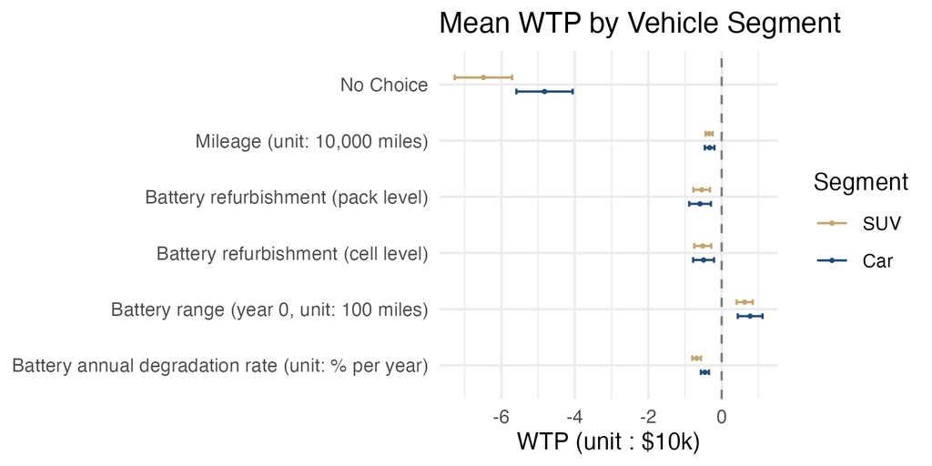

## 2.2 Heterogeneity (Mean WTP ± 1 SD)

The implied distribution of each random parameter across the population.

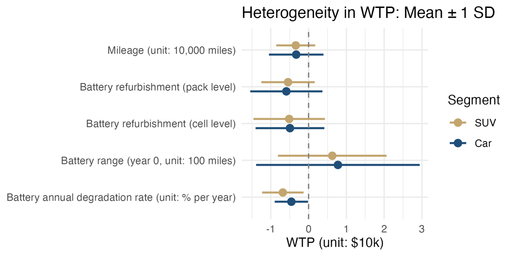

## 2.3 Simulated individual WTP distributions

The distribution can be simulated using the estimated mean and standard deviation parameters from the MXL model. This allows us to visualize the heterogeneity in WTP across individuals, showing how much variation there is in the population’s preferences for each attribute.

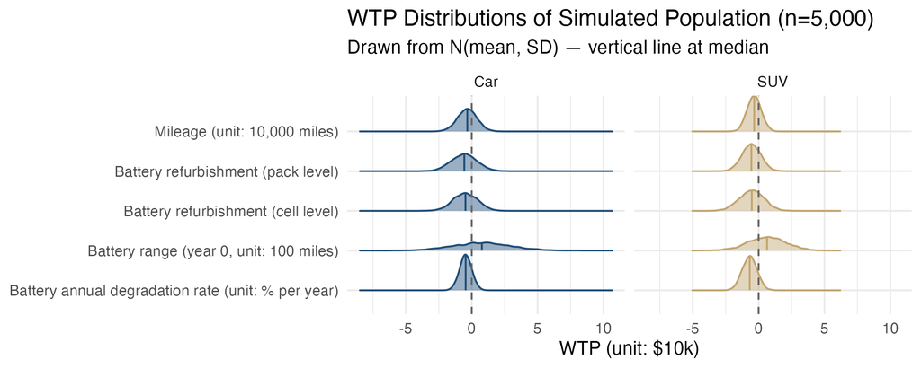

# 3 Summary of MXL+Interaction Model Results

## 3.1 Preference Space

### 3.1.1 Car

```
=================================================

Model estimated on: Tue Feb 24 12:55:48 2026

Using logitr version: 1.1.2

Call:
logitr(data = data, outcome = "choice", obsID = "obsID", pars = pars_pref,
    scalePar = set.seed(123), randPars = randPars, panelID = "respID",
    numMultiStarts = 10, drawType = "sobol", numDraws = numDraws,
    numCores = 5)

Frequencies of alternatives:
      1       2       3       4
0.22007 0.25668 0.23299 0.29027

Summary Of Multistart Runs:
   Log Likelihood Iterations Exit Status
1       -2494.163         36           3
2       -2503.387         30           3
3       -2491.699         32           3
4       -2498.847         36           3
5       -2497.577         33           3
6       -2501.579         35           3
7       -2491.382         36           3
8       -2503.281         39           3
9       -2506.473         38           3
10      -2494.162         31           3

Use statusCodes() to view the meaning of each status code

Exit Status: 3, Optimization stopped because ftol_rel or ftol_abs was reached.

Model Type:       Mixed Logit
Model Space:       Preference
Model Run:            7 of 10
Iterations:                36
Elapsed Time:        0h:0m:4s
Algorithm:     NLOPT_LD_LBFGS
Weights Used?:          FALSE
```

[output cut: 31 more lines]

```
Number of Observations:  2322.0000000

Summary of 10k Draws for Random Coefficients:
                             Min.    1st Qu.     Median       Mean     3rd Qu.
mileage                      -Inf -0.5979524 -0.2391085 -0.2394468  0.11961290
battery_range_year0          -Inf -0.7908255  0.2418695  0.2427980  1.27489250
battery_degradation          -Inf -0.5309515 -0.3057251 -0.3059665 -0.08043532
battery_refurbishpackreplace -Inf -1.0031224 -0.6155048 -0.6159979 -0.22777197
battery_refurbishcellreplace -Inf -0.8543557 -0.4343192 -0.4351760 -0.01456199
                             Max.
mileage                       Inf
battery_range_year0           Inf
battery_degradation           Inf
battery_refurbishpackreplace  Inf
battery_refurbishcellreplace  Inf
```

### 3.1.2 SUV

[output not shown]

[output cut: 31 more lines]

[output not shown]

## 3.2 WTP Space

### 3.2.1 Car

- Wealthier individuals value driving range more (drive longer distances, range as quality signal)
- People with home charging value range more (more committed EV adopters,planning regular usage,understand range better).
- Wealthier individuals dislike battery degradation more strongly (more quality sensitive,less tolerant of performance decay).
- As risk-taking perception increases, dislike of refurbished batteries becomes smaller. However, it is only significant in pack-level replcement, not cell-level replacement.

```
=================================================

Model estimated on: Tue Feb 24 12:56:24 2026

Using logitr version: 1.1.2

Call:
logitr(data = data, outcome = "choice", obsID = "obsID", pars = pars_wtp,
    scalePar = "price", randPars = randPars, randScale = set.seed(6789),
    panelID = "respID", startVals = wtp_pref_model$Estimate,
    numMultiStarts = 10, drawType = "sobol", numDraws = numDraws,
    numCores = 5)

Frequencies of alternatives:
      1       2       3       4
0.22007 0.25668 0.23299 0.29027

Summary Of Multistart Runs:
   Log Likelihood Iterations Exit Status
1       -2556.501        100           4
2       -2563.569         72           4
3       -2491.205         50           3
4       -2491.382         41           3
5       -2501.998         42           3
6       -2550.820         75           4
7       -2497.464         41           3
8       -2499.596         48           3
9       -2553.482         84           4
10      -2564.725         67           4

Use statusCodes() to view the meaning of each status code

Exit Status: 3, Optimization stopped because ftol_rel or ftol_abs was reached.

Model Type:           Mixed Logit
Model Space:   Willingness-to-Pay
Model Run:                3 of 10
Iterations:                    50
Elapsed Time:           0h:0m:13s
Algorithm:         NLOPT_LD_LBFGS
```

[output cut: 32 more lines]

```
Number of Observations:  2322.0000000

Summary of 10k Draws for Random Coefficients:
                             Min.    1st Qu.     Median       Mean     3rd Qu.
mileage                      -Inf -0.9034433 -0.3733306 -0.3728305  0.15696314
battery_range_year0          -Inf -1.1928232  0.2158506  0.2171172  1.62497194
battery_degradation          -Inf -0.7157905 -0.4336592 -0.4333568 -0.15160715
battery_refurbishpackreplace -Inf -1.4336011 -0.8762346 -0.8755258 -0.31903372
battery_refurbishcellreplace -Inf -1.1797707 -0.5718821 -0.5706412  0.03641094
                             Max.
mileage                       Inf
battery_range_year0           Inf
battery_degradation           Inf
battery_refurbishpackreplace  Inf
battery_refurbishcellreplace  Inf
```

### 3.2.2 SUV

```
=================================================

Model estimated on: Tue Feb 24 12:57:02 2026

Using logitr version: 1.1.2

Call:
logitr(data = data, outcome = "choice", obsID = "obsID", pars = pars_wtp,
    scalePar = "price", randPars = randPars, randScale = set.seed(6789),
    panelID = "respID", startVals = wtp_pref_model$Estimate,
    numMultiStarts = 10, drawType = "sobol", numDraws = numDraws,
    numCores = 5)

Frequencies of alternatives:
      1       2       3       4
0.24695 0.27025 0.23907 0.24373

Summary Of Multistart Runs:
   Log Likelihood Iterations Exit Status
1       -2805.210         76           3
2       -2915.762         86           3
3       -2807.386         47           3
4       -2806.944         45           3
5       -2817.796         42           3
6       -2913.844         78           4
7       -2807.667         40           3
8       -2808.297         48           3
9       -2922.323         71           4
10      -2918.838         77           4

Use statusCodes() to view the meaning of each status code

Exit Status: 3, Optimization stopped because ftol_rel or ftol_abs was reached.

Model Type:           Mixed Logit
Model Space:   Willingness-to-Pay
Model Run:                1 of 10
Iterations:                    76
Elapsed Time:           0h:0m:22s
Algorithm:         NLOPT_LD_LBFGS
```

[output cut: 32 more lines]

```
Number of Observations:  2790.0000000

Summary of 10k Draws for Random Coefficients:
                             Min.    1st Qu.     Median       Mean     3rd Qu.
mileage                      -Inf -0.6273322 -0.3231503 -0.3234371 -0.01907230
battery_range_year0          -Inf -0.5966208  0.3516721  0.3508197  1.29966382
battery_degradation          -Inf -0.8978815 -0.5439558 -0.5435765 -0.19012967
battery_refurbishpackreplace -Inf -0.9491326 -0.6871570 -0.6874902 -0.42510344
battery_refurbishcellreplace -Inf -1.2541603 -0.6647217 -0.6635184 -0.07489076
                             Max.
mileage                       Inf
battery_range_year0           Inf
battery_degradation           Inf
battery_refurbishpackreplace  Inf
battery_refurbishcellreplace  Inf
```

## 3.3 Compare between two spaces

### 3.3.1 Car

```
                                          pref             wtp  difference
scalePar                            0.70145320     0.717226388  0.01577319
mileage                            -0.34029628    -0.373931386 -0.03363511
battery_range_year0                 0.34411147     0.215180359 -0.12893111
battery_degradation                -0.43545466    -0.434002340  0.00145232
battery_refurbishpackreplace       -0.87606767    -0.877649561 -0.00158189
battery_refurbishcellreplace       -0.61776836    -0.573306544  0.04446181
no_choice                          -5.07784024    -5.001266605  0.07657363
interact_range_income               0.05765365     0.065059926  0.00740628
interact_range_charger              0.27637409     0.071308889 -0.20506520
interact_degradation_income        -0.00526455    -0.004841621  0.00042293
interact_refurbishpack_risk         0.74677886     0.763673201  0.01689434
interact_refurbishcell_risk         0.39466134     0.410731368  0.01607003
sd_mileage                          0.75855289    -0.786313089 -1.54486597
sd_battery_range_year0             -2.18331083    -2.089068344  0.09424249
sd_battery_degradation              0.47625755    -0.418360280 -0.89461783
sd_battery_refurbishpackreplace     0.81965632    -0.826492343 -1.64614866
sd_battery_refurbishcellreplace     0.88762579    -0.901684133 -1.78930992
logLik                          -2491.38212982 -2491.205394436  0.17673538
```

### 3.3.2 SUV

```
                                          pref            wtp  difference
scalePar                            0.79066533     0.78981975 -0.00084557
mileage                            -0.32244397    -0.32280567 -0.00036170
battery_range_year0                 0.36442694     0.35212314 -0.01230380
battery_degradation                -0.54184527    -0.54438630 -0.00254103
battery_refurbishpackreplace       -0.68583210    -0.68649173 -0.00065963
battery_refurbishcellreplace       -0.66555543    -0.66610286 -0.00054743
no_choice                          -6.36353532    -6.36900352 -0.00546821
interact_range_income               0.01980189     0.02078785  0.00098596
interact_range_charger              0.22398105     0.23150638  0.00752532
interact_degradation_income        -0.01407738    -0.01382406  0.00025332
interact_refurbishpack_risk         0.42407763     0.42426558  0.00018795
interact_refurbishcell_risk         0.12763904     0.12791300  0.00027396
sd_mileage                          0.45031159     0.45103716  0.00072557
sd_battery_range_year0              1.40431248     1.40587520  0.00156272
sd_battery_degradation             -0.52444984    -0.52482093 -0.00037109
sd_battery_refurbishpackreplace     0.38544191     0.38858675  0.00314484
sd_battery_refurbishcellreplace    -0.87215541    -0.87431733 -0.00216192
logLik                          -2805.20394427 -2805.21047419 -0.00652992
```

# 4 Self-reported importance of battery information

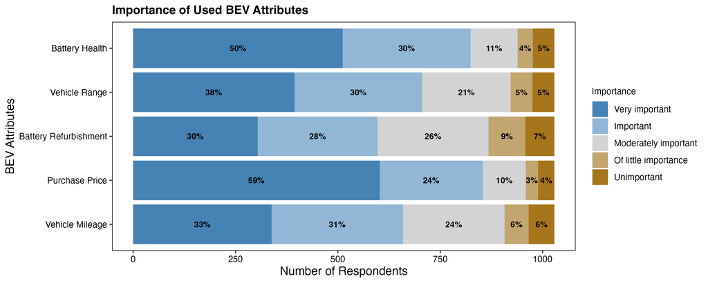

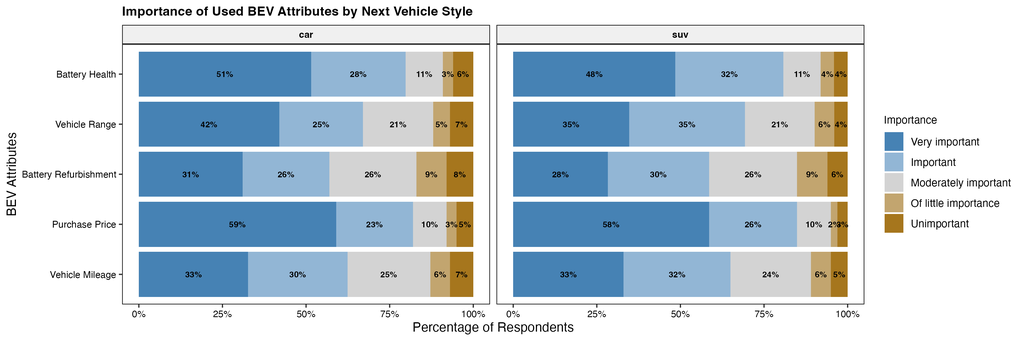

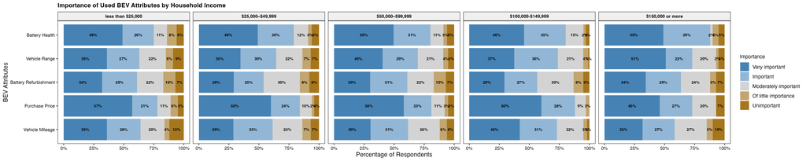